# Flanker: a tool for comparative genomics of gene flanking regions

Will Matlock and Sam Lipworth

26/01/2021

This R markdown script accompanies the manuscript “Flanker: a tool for comparative genomics of gene flanking regions” (Matlock/Lipworth et al 2021). Work through the code chunks sequentially or you can knit it. Any issues/questions please email samuel.lipworth@ndm.ox.ac.uk (wrote this R code) or william.matlock@wadham.ox.ac.uk / twitter @samlipworth @wtmatlock

Essentially we do three things: 1) take flanker output and classify Flank Patterns (Overall pattern over all window clusters) 2) plot a mashtree of plasmid assemblies 3) plot an schematic alignment of genes using gggenes

We then slot all these together in a facet plot and add some info on presence/absence of plasmids as called by Plasmidfinder.

This should be generally useful for anyone wanting to take Prokka output and plot an alignment against a tree.

```
## [1] 7
```

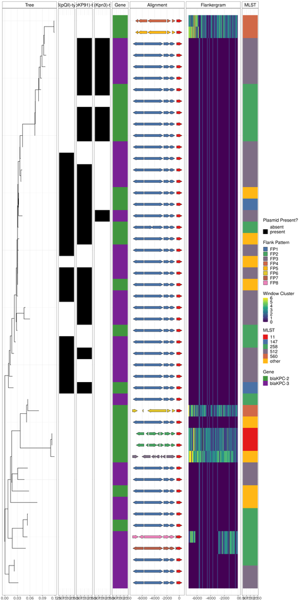

```
## [1] 7
```

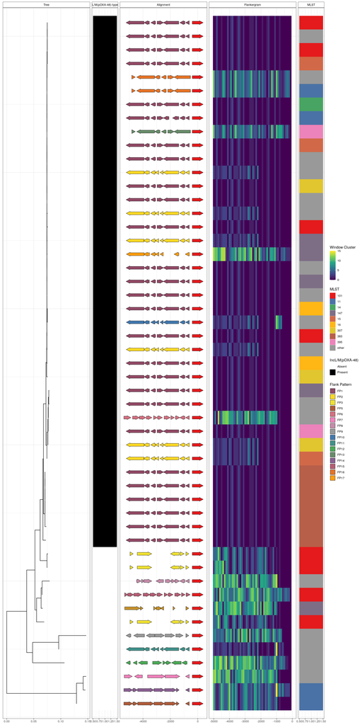

Here we took a single representative member of each flank pattern (FP) and sketched these using Mash (on default settings). We then performed a mash screen against assemblies of all EUSCAPE isolates and assigned these to the top hit - e.g. mash screen FPs.msh file.fasta | sort -gk1 | tail -1

```
##
##  Fisher's Exact Test for Count Data with simulated p-value (based on
##  2000 replicates)
##
## data:  t
## p-value = 0.0004998
## alternative hypothesis: two.sided
```

```
##
##  Fisher's Exact Test for Count Data
##
## data:  t
## p-value = 0.005266
## alternative hypothesis: two.sided
```

```
##
##  Fisher's Exact Test for Count Data
##
## data:  t
## p-value = 0.5487
## alternative hypothesis: true odds ratio is not equal to 1
## 95 percent confidence interval:
##  0.05360409 2.12687207
## sample estimates:
## odds ratio
##  0.4890097
```

```
##
##  FP1.fasta FP12.fasta  FP2.fasta  FP3.fasta  FP4.fasta  FP5.fasta  FP7.fasta
##         12          4          1        150          4          8        244
##  FP9.fasta
##          2
```

```
##
##             >32 ≤0.06 0.12 0.25 0.5  1 16  2 32  4  8
##   FP1.fasta   0     0    0    0   0  1  0  1  0  1  0
##   FP2.fasta   0     1    0    0   0  0  0  0  0  0  0
##   FP3.fasta   7     2    0    0   5 26  4 18  5  4  2
##   FP4.fasta   0     0    0    0   1  0  0  0  0  0  0
##   FP5.fasta   2     0    1    0   0  0  0  0  1  0  0
##   FP7.fasta  17     2    1    2   8 18 19 27 36  9  3
##   FP9.fasta   0     0    0    0   0  0  0  0  0  2  0
```

```
##
## FP1.fasta FP2.fasta FP3.fasta FP4.fasta FP5.fasta FP7.fasta FP9.fasta
##         3         1        73         1         4       142         2
```

| guuid | Flanker 500bp | Flanker 5000bp | Flanker 7200bp | MEFinder 500bp | MEFinder 5000bp | TETyper 500bp | TETyper 5000bp | TETyper Tn4401 whole |
| --- | --- | --- | --- | --- | --- | --- | --- | --- |
| CABFYD010000003.1 | 0 | 0 | 1 | Tn4401\|1\|KT378596.1 | Tn4401\|1\|KT378596.1 | 1-6602\|7020-7118\|7202-10006 | 1-2202\|7020-7118\|7202-10006 | Tn4401a |
| MT560073.1 | 0 | 0 | 1 | Tn4401\|1\|KT378596.1 | Tn4401\|1\|KT378596.1 | 1-6602\|7020-7118\|7202-10006 | 1-2202\|7020-7118\|7202-10006 | unknown |
| CABFYQ010000002.1 | 0 | 0 | 1 | Tn4401\|1\|KT378596.1 | Tn4401\|1\|KT378596.1 | 1-6602\|7020-7118\|7202-10006 | 1-2202\|7020-7118\|7202-10006 | Tn4401a |
| CABFZV010000006.1 | 0 | 0 | 1 | Tn4401\|1\|KT378596.1 | Tn4401\|1\|KT378596.1 | 1-6602\|7020-7118\|7202-10006 | 1-2202\|7020-7118\|7202-10006 | Tn4401a |
| CABGAG010000002.1 | 0 | 0 | 1 | Tn4401\|1\|KT378596.1 | Tn4401\|1\|KT378596.1 | 1-6602\|7020-7118\|7202-10006 | 1-2202\|7020-7118\|7202-10006 | Tn4401a |
| CABFYI010000002.1 | 0 | 0 | 1 | Tn4401\|1\|KT378596.1 | Tn4401\|1\|KT378596.1 | 1-6602\|7020-7118\|7202-10006 | 1-2202\|7020-7118\|7202-10006 | Tn4401a |
| CABGAO010000002.1 | 0 | 0 | 1 | Tn4401\|1\|KT378596.1 | Tn4401\|1\|KT378596.1 | 1-6602\|7020-7118\|7202-10006 | 1-2202\|7020-7118\|7202-10006 | Tn4401a |
| CABFYF010000002.1 | 0 | 0 | 1 | Tn4401\|1\|KT378596.1 | Tn4401\|1\|KT378596.1 | 1-6602\|7020-7118\|7202-10006 | 1-2202\|7020-7118\|7202-10006 | Tn4401a |
| CABFYH010000003.1 | 0 | 0 | 1 | Tn4401\|1\|KT378596.1 | Tn4401\|1\|KT378596.1 | 1-6602\|7020-7118\|7202-10006 | 1-2202\|7020-7118\|7202-10006 | Tn4401a |
| MT560060.1 | 0 | 0 | 1 | Tn4401\|1\|KT378596.1 | Tn4401\|1\|KT378596.1 | 1-6602\|7020-7118\|7202-10006 | 1-2202\|7020-7118\|7202-10006 | unknown |
| CABGAI010000003.1 | 0 | 0 | 1 | Tn4401\|1\|KT378596.1 | Tn4401\|1\|KT378596.1 | 1-6602\|7020-7118\|7202-10006 | 1-2202\|7020-7118\|7202-10006 | Tn4401a |
| CABGAZ010000003.1 | 0 | 0 | 1 | Tn4401\|1\|KT378596.1 | Tn4401\|1\|KT378596.1 | 1-6602\|7020-7118\|7202-10006 | 1-2202\|7020-7118\|7202-10006 | Tn4401a |
| CABFYZ010000002.1 | 0 | 0 | 1 | Tn4401\|1\|KT378596.1 | Tn4401\|1\|KT378596.1 | 1-6602\|7020-7118\|7202-10006 | 1-2202\|7020-7118\|7202-10006 | Tn4401a |
| CABGAQ010000009.1 | 0 | 0 | 1 | Tn4401\|1\|KT378596.1 | Tn4401\|1\|KT378596.1 | 1-6602\|7020-7118\|7202-10006 | 1-2202\|7020-7118\|7202-10006 | Tn4401a |
| CABGBS010000004.1 | 0 | 0 | 1 | Tn4401\|1\|KT378596.1 | Tn4401\|1\|KT378596.1 | 1-6602\|7020-7118\|7202-10006 | 1-2202\|7020-7118\|7202-10006 | Tn4401a |
| CABFYU010000005.1 | 0 | 0 | 1 | Tn4401\|1\|KT378596.1 | Tn4401\|1\|KT378596.1 | 1-6602\|7020-7118\|7202-10006 | 1-2202\|7020-7118\|7202-10006 | Tn4401a |
| CABGAR010000003.1 | 0 | 0 | 1 | Tn4401\|1\|KT378596.1 | Tn4401\|1\|KT378596.1 | 1-6602\|7020-7118\|7202-10006 | 1-2202\|7020-7118\|7202-10006 | Tn4401a |
| MT560075.1 | 0 | 0 | 1 | Tn4401\|1\|KT378596.1 | Tn4401\|1\|KT378596.1 | 1-6602\|7020-7118\|7202-10006 | 1-2202\|7020-7118\|7202-10006 | unknown |
| CABFZA010000002.1 | 0 | 0 | 1 | Tn4401\|1\|KT378596.1 | Tn4401\|1\|KT378596.1 | 1-6602\|7020-7118\|7202-10006 | 1-2202\|7020-7118\|7202-10006 | Tn4401a |
| CABFXY010000002.1 | 0 | 0 | 1 | Tn4401\|1\|KT378596.1 | Tn4401\|1\|KT378596.1 | 1-6602\|7020-7118\|7202-10006 | 1-2202\|7020-7118\|7202-10006 | Tn4401a |
| CABFZG010000005.1 | 0 | 0 | 1 | Tn4401\|1\|KT378596.1 | Tn4401\|1\|KT378596.1 | 1-6602\|7020-7118\|7202-10006 | 1-2202\|7020-7118\|7202-10006 | Tn4401a |
| CABFYK010000005.1 | 0 | 0 | 1 | Tn4401\|1\|KT378596.1 | Tn4401\|1\|KT378596.1 | 1-6602\|7020-7118\|7202-10006 | 1-2202\|7020-7118\|7202-10006 | Tn4401a |
| CABFXS010000003.1 | 0 | 0 | 1 | Tn4401\|1\|KT378596.1 | Tn4401\|1\|KT378596.1 | 1-6602\|7020-7118\|7202-10006 | 1-2202\|7020-7118\|7202-10006 | Tn4401a |
| CABFYY010000002.1 | 0 | 0 | 1 | Tn4401\|1\|KT378596.1 | Tn4401\|1\|KT378596.1 | 1-6602\|7020-7118\|7202-10006 | 1-2202\|7020-7118\|7202-10006 | Tn4401a |
| CABGAY010000002.1 | 0 | 0 | 1 | Tn4401\|1\|KT378596.1 | Tn4401\|1\|KT378596.1 | 1-6602\|7020-7118\|7202-10006 | 1-2202\|7020-7118\|7202-10006 | Tn4401a |
| CABGBH010000002.1 | 0 | 0 | 1 | Tn4401\|1\|KT378596.1 | Tn4401\|1\|KT378596.1 | 1-6602\|7020-7118\|7202-10006 | 1-2202\|7020-7118\|7202-10006 | Tn4401a |
| CABFYC010000004.1 | 0 | 0 | 1 | Tn4401\|1\|KT378596.1 | Tn4401\|1\|KT378596.1 | 1-6602\|7020-7118\|7202-10006 | 1-2202\|7020-7118\|7202-10006 | Tn4401a |
| CABFYE010000002.1 | 0 | 0 | 1 | Tn4401\|1\|KT378596.1 | Tn4401\|1\|KT378596.1 | 1-6602\|7020-7118\|7202-10006 | 1-2202\|7020-7118\|7202-10006 | Tn4401a |
| CABGAK010000004.1 | 0 | 0 | 1 | Tn4401\|1\|KT378596.1 | Tn4401\|1\|KT378596.1 | 1-6602\|7020-7118\|7202-10006 | 1-2202\|7020-7118\|7202-10006 | Tn4401a |
| CABFYG010000003.1 | 0 | 0 | 1 | Tn4401\|1\|KT378596.1 | Tn4401\|1\|KT378596.1 | 1-6602\|7020-7118\|7202-10006 | 1-2202\|7020-7118\|7202-10006 | Tn4401a |
| CABGAX010000009.1 | 0 | 0 | 1 | Tn4401\|1\|KT378596.1 | Tn4401\|1\|KT378596.1 | 1-6602\|7020-7118\|7202-10006 | 1-2203\|7020-7118\|7202-10006 | Tn4401a |
| CABFXR010000002.1 | 0 | 0 | 1 | Tn4401\|1\|KT378596.1 | Tn4401\|1\|KT378596.1 | 1-6602\|7020-7118\|7202-10006 | 1-2202\|7020-7118\|7202-10006 | Tn4401a |
| CABFYB010000005.1 | 0 | 0 | 1 | Tn4401\|1\|KT378596.1 | Tn4401\|1\|KT378596.1 | 1-6602\|7020-7118\|7202-10006 | 1-2202\|7020-7118\|7202-10006 | Tn4401a |
| CABFYS010000003.1 | 0 | 0 | 1 | Tn4401\|1\|KT378596.1 | Tn4401\|1\|KT378596.1 | 1-6602\|7020-7118\|7202-10006 | 1-2202\|7020-7118\|7202-10006 | Tn4401a |
| CABFYL010000004.1 | 0 | 0 | 1 | Tn4401\|1\|KT378596.1 | Tn4401\|1\|KT378596.1 | 1-6602\|7020-7118\|7202-10006 | 1-2202\|7020-7118\|7202-10006 | Tn4401a |
| CABFYT010000008.1 | 0 | 0 | 1 | Tn4401\|1\|KT378596.1 | Tn4401\|1\|KT378596.1 | 1-6602\|7020-7118\|7202-10006 | 1-2202\|7020-7118\|7202-10006 | Tn4401a |
| MT560078.1 | 0 | 0 | 1 | Tn4401\|1\|KT378596.1 | Tn4401\|1\|KT378596.1 | 1-6602\|7020-7118\|7202-10006 | 1-2202\|7020-7118\|7202-10006 | unknown |
| CABGBM010000006.1 | 0 | 0 | 1 | Tn4401\|1\|KT378596.1 | Tn4401\|1\|KT378596.1 | 1-6602\|7020-7118\|7202-10006 | 1-2202\|7020-7118\|7202-10006 | Tn4401a |
| CABFYN010000003.1 | 0 | 0 | 1 | Tn4401\|1\|KT378596.1 | Tn4401\|1\|KT378596.1 | 1-6602\|7020-7118\|7202-10006 | 1-2202\|7020-7118\|7202-10006 | Tn4401a |
| CABFZZ010000003.1 | 0 | 0 | 1 | Tn4401\|1\|KT378596.1 | Tn4401\|1\|KT378596.1 | 1-6602\|7020-7118\|7202-10006 | 1-2202\|7020-7118\|7202-10006 | Tn4401a |
| CABFZH010000004.1 | 0 | 0 | 1 | Tn4401\|1\|KT378596.1 | Tn4401\|1\|KT378596.1 | 1-6602\|7020-7118\|7202-10006 | 1-2202\|7020-7118\|7202-10006 | Tn4401a |
| CABFYM010000002.1 | 0 | 0 | 1 | Tn4401\|1\|KT378596.1 | Tn4401\|1\|KT378596.1 | 1-6602\|7020-7118\|7202-10006 | 1-2202\|7020-7118\|7202-10006 | Tn4401a |
| MT560080.1 | 1 | 3 | 5 | No hits | Tn1000\|1\|X60200.1 | 1-7127\|7202-10006 | 1-7127\|7202-10006 | unknown |
| MT560061.1 | 1 | 3 | 4 | No hits | Tn1000\|1\|X60200.1 | 1-7127\|7202-10006 | 1-7127\|7202-10006 | unknown |
| MT560063.1 | 1 | 2 | 6 | No hits | Tn1000\|1\|X60200.1 | 1-7127\|7202-10006 | 1-7127\|7202-10006 | unknown |
| CABFYR010000005.1 | 2 | 1 | 2 | No hits | Tn6296\|1\|FJ628167 | 1-7127\|7202-10006 | 1-7127\|7202-10006 | Tn4401_truncC |
| CABGBR010000009.1 | 2 | 1 | 2 | No hits | Tn6296\|1\|FJ628167 | 1-7127\|7202-10006 | 1-7127\|7202-10006 | Tn4401_truncC |
| MT560066.1 | 2 | 4 | 3 | No hits | No hits | 1-7127\|7202-10006 | 1-7127\|7202-10006 | unknown |
| CABFYJ010000003.1 | 3 | 0 | 8 | Tn4401\|1\|KT378596.1 | Tn4401\|1\|KT378596.1 | 1-6633\|7008-7075\|7202-10006 | 1-2233\|7008-7075\|7202-10006 | unknown |
| CABFZC010000002.1 | 3 | 0 | 7 | Tn4401\|1\|KT378596.1 | Tn4401\|1\|KT378596.1 | 1-6633\|7008-7075\|7202-10006 | 1-2233\|7008-7075\|7202-10006 | Tn4401d |